# February Survey Report

Maksim Zubok

2024-03-15

## Intro

To create weights, I am working with the 2020 [census data](https://github.com/antndlcrx/nonviolent-repression/blob/main/data/surveys/Tom3_tab1_VPN-2020.xlsx), particularly the cross tabbed gender, age, and university education file [here](https://github.com/antndlcrx/nonviolent-repression/blob/main/data/surveys/ru_population_frame.csv).

I did not include information about region of residence, even though we could do it after harmonising census data with the survey.

```r
head(ru_population_frame, 5)
```

```
## # A tibble: 5 x 4
## # Groups:   gender [1]
##   gender  age_group university_education    Freq
##   <fct>   <chr>     <chr>                  <dbl>
## 1 Мужской 18-24     BA+                   463546
## 2 Мужской 18-24     BA-                  5164261
## 3 Мужской 25-34     BA+                  2707302
## 4 Мужской 25-34     BA-                  7287296
## 5 Мужской 35-44     BA+                  3136411
```

## Sample to Population Comparison

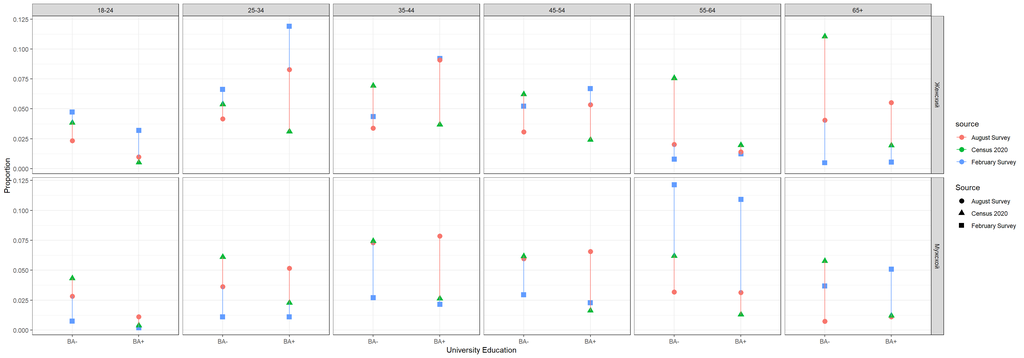

## Weights witth Survey package

To compute post-stratification weights we rely on the `postStratify` function from the `survey` package. The function adjusts the sampling and replicate weights so that the joint distribution of a set of post-stratifying variables matches the known population joint distribution. **However, the package documentation does not describe how exactly the adjustment is implemented.**

```r
## survey library ##
unweighted_data <- svydesign(ids = ~1, data = survey_feb)


weighted <- postStratify(unweighted_data, ~age_group + gender + university_education,
             ru_population_frame, partial=TRUE)

# save weights
survey_feb$weight <- weights(weighted)
sum_feb <- summary(weights(weighted))
sum_feb
```

```
##    Min. 1st Qu.  Median    Mean 3rd Qu.    Max.
##    8670   19144   37348   73292   87350 1649629
```

Note: some strata had no observations in the survey (NA on education for some age gender groups). This means we had to ignore them in producing weights.

```r
## survey library ##
unweighted_data <- svydesign(ids = ~1, data = survey_aug)


weighted <- postStratify(unweighted_data, ~age_group + gender + university_education,
             ru_population_frame, partial=TRUE)

# save weights
survey_aug$weight <- weights(weighted)
sum_aug <- summary(weights(weighted))
sum_aug
```

```
##    Min. 1st Qu.  Median    Mean 3rd Qu.    Max.
##   18134   27511   33083   74667  112267  574251
```

For August, we also see that some weights are much larger than others. As you can see in the graphs below, the distribution of weights is similarly skewed and the disparities between the bulk of the distribution and its tales are in the same orders of magnitude. However, the largest weight in Feb survey is three times bigger than the largest weight in Aug survey.

The largest weights in both surveys relate to different population groups.

February Survey, Top Five Rows by Weight

| age_group | gender | university_education | weight |
| --- | --- | --- | --- |
| 65+ | Женский | BA- | 1649629 |
| 65+ | Женский | BA- | 1649629 |
| 65+ | Женский | BA- | 1649629 |
| 65+ | Женский | BA- | 1649629 |
| 65+ | Женский | BA- | 1649629 |

August Survey, Top Five Rows by Weight

| age_group | gender | university_education | weight |
| --- | --- | --- | --- |
| 65+ | Мужской | BA- | 574250.5 |
| 65+ | Мужской | BA- | 574250.5 |
| 65+ | Мужской | BA- | 574250.5 |
| 65+ | Мужской | BA- | 574250.5 |
| 65+ | Мужской | BA- | 574250.5 |

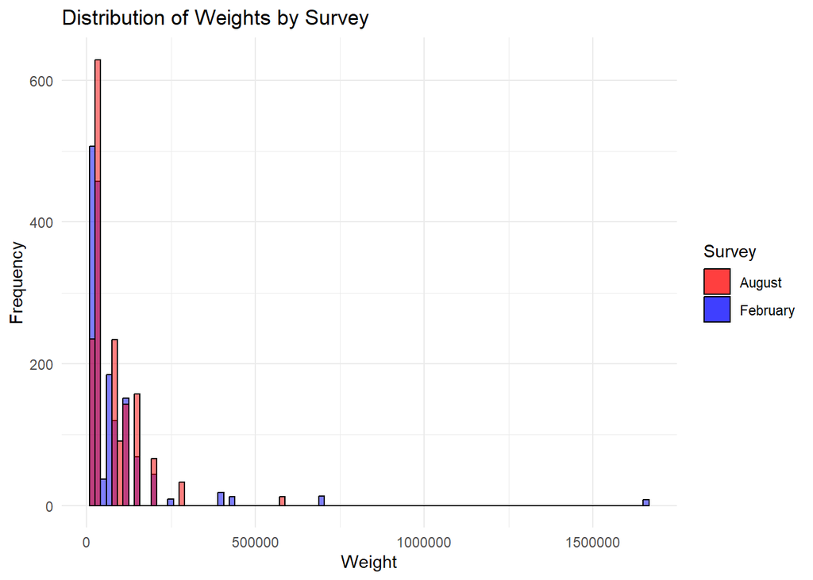

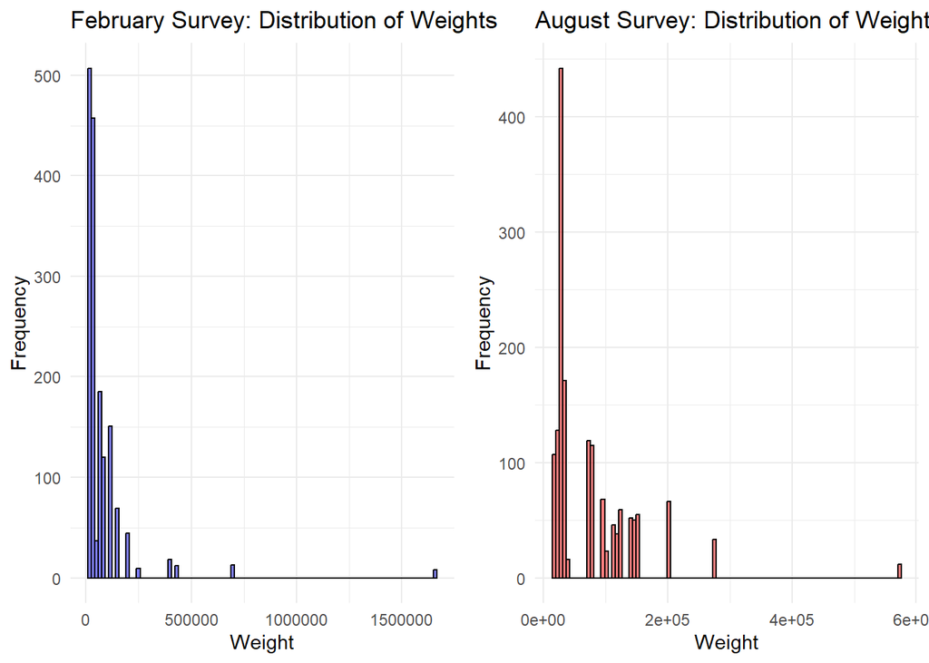

## Weights created manually

To check the plausibility of resulting weights, we create alternative weights based on the population frequencies of the combination of the same strata (Yana’s approach). The weights are calculated for each category:
$$\text{weight}_i =
\frac{\text{population frequency}_i}{\text{sample frequency}_i}$$

```r
# calculate weights and print the df with weights
weights_aug_strata <- left_join(survey_aug_strata,
                            pop_strata,
                            c("gender", "age_group", "university_education")) %>%
  rename(population_proportion = proportion.y,
         sample_proportion = proportion.x)  %>%
  # calculate weights as popul prop/sample prop
  mutate(weight = population_proportion / sample_proportion)

sum_man_aug <-summary(weights_aug_strata$weight)
sum_man_aug
```

```
##    Min. 1st Qu.  Median    Mean 3rd Qu.    Max.
##  0.2474  0.4110  1.0654  1.4550  1.7490  7.8351
```

```r
# calculate weights and print the df with weights
weights_feb_strata <- left_join(survey_feb_strata,
                            pop_strata,
                            c("gender", "age_group", "university_education")) %>%
  rename(population_proportion = proportion.y,
         sample_proportion = proportion.x)  %>%
  # calculate weights as popul prop/sample prop
  mutate(weight = population_proportion / sample_proportion)

# head(weights_feb_strata)
sum_man_feb <- summary(weights_feb_strata$weight)
sum_man_feb
```

```
##    Min. 1st Qu.  Median    Mean 3rd Qu.    Max.
##  0.1183  0.4821  1.3948  2.8112  2.2694 22.5075
```

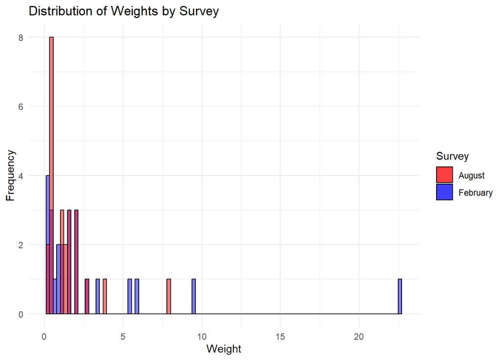

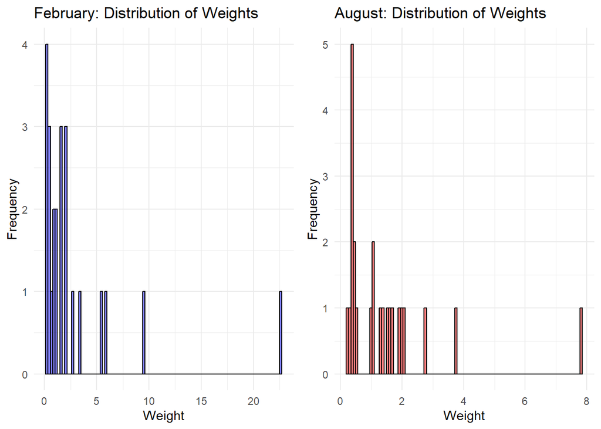

Calculating weights this way gives us the same overall picture. The main difference is in the orders of magnitude between the median weight and the tail (highest weight).

For **February** survey, the difference (max weight / median weight) with `postStratify` is **44.17**, but with simple manually created weights it is **16.14**. For **August** survey, the difference with `postStratify` is **17.36**, but with simple manually created weights it is **7.35**.